# PCA_FoodConsumption

#### The data food-consumption.csv contains 16 countries in Europe and their consumption for 20 food items, such as tea, jam, coffee, yogurt, and others. We will perform principal component analysis to explore the data.

| Country | Real coffee | Instant coffee | Tea | Sweetener | Biscuits | Powder soup | Tin soup | Potatoes | Frozen fish | Frozen veggies | Apples | Oranges | Tinned fruit | Jam | Garlic | Butter | Margarine | Olive oil | Yoghurt | Crisp bread |
| --- | --- | --- | --- | --- | --- | --- | --- | --- | --- | --- | --- | --- | --- | --- | --- | --- | --- | --- | --- | --- |
| Germany | 90 | 49 | 88 | 19 | 57 | 51 | 19 | 21 | 27 | 21 | 81 | 75 | 44 | 71 | 22 | 91 | 85 | 74 | 30 | 26 |
| Italy | 82 | 10 | 60 | 2 | 55 | 41 | 3 | 2 | 4 | 2 | 67 | 71 | 9 | 46 | 80 | 66 | 24 | 94 | 5 | 18 |
| France | 88 | 42 | 63 | 4 | 76 | 53 | 11 | 23 | 11 | 5 | 87 | 84 | 40 | 45 | 88 | 94 | 47 | 36 | 57 | 3 |
| Holland | 96 | 62 | 98 | 32 | 62 | 67 | 43 | 7 | 14 | 14 | 83 | 89 | 61 | 81 | 15 | 31 | 97 | 13 | 53 | 15 |
| Belgium | 94 | 38 | 48 | 11 | 74 | 37 | 23 | 9 | 13 | 12 | 76 | 76 | 42 | 57 | 29 | 84 | 80 | 83 | 20 | 5 |
| Luxembourg | 97 | 61 | 86 | 28 | 79 | 73 | 12 | 7 | 26 | 23 | 85 | 94 | 83 | 20 | 91 | 94 | 94 | 84 | 31 | 24 |
| England | 27 | 86 | 99 | 22 | 91 | 55 | 76 | 17 | 20 | 24 | 76 | 68 | 89 | 91 | 11 | 95 | 94 | 57 | 11 | 28 |
| Portugal | 72 | 26 | 77 | 2 | 22 | 34 | 1 | 5 | 20 | 3 | 22 | 51 | 8 | 16 | 89 | 65 | 78 | 92 | 6 | 9 |
| Austria | 55 | 31 | 61 | 15 | 29 | 33 | 1 | 5 | 15 | 11 | 49 | 42 | 14 | 41 | 51 | 51 | 72 | 28 | 13 | 11 |
| Switzerland | 73 | 72 | 85 | 25 | 31 | 69 | 10 | 17 | 19 | 15 | 79 | 70 | 46 | 61 | 64 | 82 | 48 | 61 | 48 | 30 |
| Sweden | 97 | 13 | 93 | 31 | 61 | 43 | 43 | 39 | 54 | 45 | 56 | 78 | 53 | 75 | 9 | 68 | 32 | 48 | 2 | 93 |
| Denmark | 96 | 17 | 92 | 35 | 66 | 32 | 17 | 11 | 51 | 42 | 81 | 72 | 50 | 64 | 11 | 92 | 91 | 30 | 11 | 34 |
| Norway | 92 | 17 | 83 | 13 | 62 | 51 | 4 | 17 | 30 | 15 | 61 | 72 | 34 | 51 | 11 | 63 | 94 | 28 | 2 | 62 |
| Finland | 98 | 12 | 84 | 20 | 64 | 27 | 10 | 8 | 18 | 12 | 50 | 57 | 22 | 37 | 15 | 96 | 94 | 17 | 21 | 64 |
| Spain | 70 | 40 | 40 | 18 | 62 | 43 | 2 | 14 | 23 | 7 | 59 | 77 | 30 | 38 | 86 | 44 | 51 | 91 | 16 | 13 |
| Ireland | 30 | 52 | 99 | 11 | 80 | 75 | 18 | 2 | 5 | 3 | 57 | 52 | 46 | 89 | 5 | 97 | 25 | 31 | 3 | 9 |

### Performing PCA on countries by treating each country's food consumption as their feature vectors. Extracting the first 2 principal components and plotting a scatter plot of results.

```
Original data matrix  (16, 20)
```

```
Covariance Matrix is :  (20, 20)
```

```
(16,)
```

```
(16,)
```

Features = Food items  
Data points = Countries

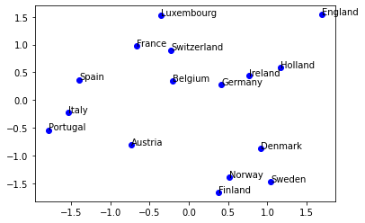

#### Observation and results

From the scatter plot, we can make some interpretation based on the direction along a specific principal component. In this case, the features are the food items. For eg, the X-axis corresponds to the subspace of the first principal component, and based on the position of Portugal and Sweden, we can infer that they have opposite food consumption patterns since they are in the opposite directions of the subspace.  
Similarly, when we observe along the direction of the second principal component (Y axis), we can infer that Luxembourg and Austria have opposite food item consumption patterns.  
We will not be able to exactly state which food item is mostly consumed in which country since the principal component is a linear combination of all food items, and can help with the direction of food consumption only.

### Performing PCA analysis on the data by treating country consumptions as feature vectors for each food item. Extracting the first 2 principal components and plotting a scatter plot of results.

```
Shape of data matrix is:  (20, 16)
Covariance Matrix is :  (16, 16)
```

```
(20,)
```

```
(20,)
```

Features = Countries  
Data points = Food items

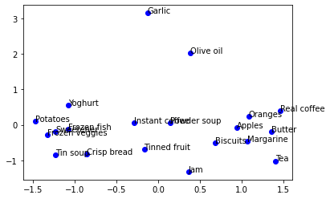

#### Observation and results

Similar to the above, we can make some inference based on the direction along a specific principal component. In this case, the features are countries.  
For eg, the X-axis corresponds to the subspace of the first principal component, and based on the position of Tea and Tin Soup, we can infer those countries these food items are consumed in opposite patterns (countries that consume Tea would not consume Tin soup).  
Similarly, when we observe along the direction of the second principal component (Y axis), we can infer that Garlic and Jam have opposite food consumption patterns among the countries.  
We will not be able to exactly state which country consumes which food item since the principal component is a linear combination of all countries in this case, and can help with the direction of food consumption only.